# Parcial final - parte practica

Kevin Zarama

16/4/2021

Carga de datos

```r
datos <- na.omit(read.csv("datos.orginales.csv"))
```

Explicacion de las variables usadas en el modelo.

- int: tasa de interés hipotecaria (en decimales)
- precio.Metro2.casa: precio promedio del metro cuadrado de las casas en el vecindario al momento de la venta en millones de pesos
- precio.Metro2.apart: precio promedio del metro cuadrado de los apartamentos en el vecindario
- n.banos: número de baños en el inmueble
- n.medio.banos: número de medio-baños (sin ducha) en el inmueble
- n.hab: número de habitaciones en el inmueble
- zona: zona dónde se encuentra ubicado el inmueble 1= sur, 2= norte, 3 = oriente, 4 = occidente, 5 = centro
- n.parqueaderos: número de parqueaderos en el inmueble
- tipo.inmueble: tipo de inmueble. apartamento (0) casa (1)
- m.cuadra: metros cuadrados del inmueble
- km.parque: distancia al parque más cercano (en km)
- km.centrocom: distancia al centro comercial más cercano (en km)
- km.estadio distancia al estadio de fútbol mas grande de la ciudad (en km).
- Valor.Venta: Valor de la transacción del inmueble (en millones de pesos)

```r
head(datos)
```

```
##   X Valor.Venta   int precio.Metro2.casa precio.Metro2.apart n.banos
## 1 1    2847.712 0.088           8.687538            2.763218       2
## 2 2    3092.550 0.075           8.387230            6.556797       3
## 3 3    3193.610 0.091           8.098284            5.376245       3
## 4 4    3182.829 0.087           7.824075            7.314454       3
## 5 5    3135.283 0.073           8.764627            6.343460       2
## 6 6    2892.098 0.087           6.792364            3.281246       2
##   n.medio.banos n.hab zona n.parqueaderos tipo.inmueble m.cuadra km.parque
## 1             1     1    5              1             0    201.2     20.56
## 2             2     2    2              3             0    196.6     22.98
## 3             1     3    5              2             0    195.2     17.89
## 4             1     3    3              1             0    197.4      7.75
## 5             1     2    3              2             1    202.0     15.59
## 6             1     1    2              3             0    202.6     21.16
##   km.centrocom km.estadio
## 1         0.70      48.11
## 2         1.28     178.69
## 3         6.25     157.43
## 4         0.87     107.82
## 5         9.33     173.67
## 6         1.55      81.86
```

Se procedera a eliminar la columna 1, ya que esta corresponde a el orden de los datos y no tiene relevancia para esto.

```r
datos <- datos[, -1]
```

```r
head(datos)
```

```
##   Valor.Venta   int precio.Metro2.casa precio.Metro2.apart n.banos
## 1    2847.712 0.088           8.687538            2.763218       2
## 2    3092.550 0.075           8.387230            6.556797       3
## 3    3193.610 0.091           8.098284            5.376245       3
## 4    3182.829 0.087           7.824075            7.314454       3
## 5    3135.283 0.073           8.764627            6.343460       2
## 6    2892.098 0.087           6.792364            3.281246       2
##   n.medio.banos n.hab zona n.parqueaderos tipo.inmueble m.cuadra km.parque
## 1             1     1    5              1             0    201.2     20.56
## 2             2     2    2              3             0    196.6     22.98
## 3             1     3    5              2             0    195.2     17.89
## 4             1     3    3              1             0    197.4      7.75
## 5             1     2    3              2             1    202.0     15.59
## 6             1     1    2              3             0    202.6     21.16
##   km.centrocom km.estadio
## 1         0.70      48.11
## 2         1.28     178.69
## 3         6.25     157.43
## 4         0.87     107.82
## 5         9.33     173.67
## 6         1.55      81.86
```

El tamaño de la muestra de los datos

```r
dim(datos)
```

```
## [1] 2536   14
```

Se puede notar que todas las variables son numericas, por lo cual no hace falta transformar las variables ni hacer uso de dummies

```r
str(datos)
```

```
## 'data.frame':    2536 obs. of  14 variables:
##  $ Valor.Venta        : num  2848 3093 3194 3183 3135 ...
##  $ int                : num  0.088 0.075 0.091 0.087 0.073 0.087 0.08 0.075 0.063 0.096 ...
##  $ precio.Metro2.casa : num  8.69 8.39 8.1 7.82 8.76 ...
##  $ precio.Metro2.apart: num  2.76 6.56 5.38 7.31 6.34 ...
##  $ n.banos            : int  2 3 3 3 2 2 1 1 2 3 ...
##  $ n.medio.banos      : int  1 2 1 1 1 1 1 1 1 2 ...
##  $ n.hab              : int  1 2 3 3 2 1 1 1 2 2 ...
##  $ zona               : int  5 2 5 3 3 2 2 2 3 5 ...
##  $ n.parqueaderos     : int  1 3 2 1 2 3 3 3 2 1 ...
##  $ tipo.inmueble      : int  0 0 0 0 1 0 1 0 0 1 ...
##  $ m.cuadra           : num  201 197 195 197 202 ...
##  $ km.parque          : num  20.56 22.98 17.89 7.75 15.59 ...
##  $ km.centrocom       : num  0.7 1.28 6.25 0.87 9.33 1.55 7.23 2.13 7.16 0.37 ...
##  $ km.estadio         : num  48.1 178.7 157.4 107.8 173.7 ...
```

Dado a que todas las variables son numericas, se procedera a realizar el metodo de seleccion automatico de modelos con los metodos de forward y backward

## Stepwise regression

Modelo con todas las variables

```r
max.model <- lm(Valor.Venta ~ ., datos)
summary(max.model)
```

```
##
## Call:
## lm(formula = Valor.Venta ~ ., data = datos)
##
## Residuals:
##     Min      1Q  Median      3Q     Max
## -806.98  -12.42   -0.35   10.80 1433.32
##
## Coefficients:
##                       Estimate Std. Error t value Pr(>|t|)
## (Intercept)          1.005e+03  5.702e+01  17.617  < 2e-16 ***
## int                 -8.851e+01  6.471e+01  -1.368 0.171530
## precio.Metro2.casa   2.455e+01  9.398e-01  26.124  < 2e-16 ***
## precio.Metro2.apart  5.058e+00  6.187e-01   8.176 4.59e-16 ***
## n.banos              1.029e+02  1.933e+00  53.239  < 2e-16 ***
## n.medio.banos       -8.152e-01  1.908e+00  -0.427 0.669289
## n.hab                1.474e+02  1.958e+00  75.274  < 2e-16 ***
## zona                 6.623e-01  6.806e-01   0.973 0.330620
## n.parqueaderos       3.276e+01  1.286e+00  25.478  < 2e-16 ***
## tipo.inmueble        1.004e+02  1.869e+00  53.703  < 2e-16 ***
## m.cuadra             5.879e+00  2.806e-01  20.951  < 2e-16 ***
## km.parque            1.935e+00  1.098e-01  17.624  < 2e-16 ***
## km.centrocom         1.208e+00  3.360e-01   3.595 0.000331 ***
## km.estadio          -3.411e-03  1.634e-02  -0.209 0.834660
## ---
## Signif. codes:  0 '***' 0.001 '**' 0.01 '*' 0.05 '.' 0.1 ' ' 1
##
## Residual standard error: 46.87 on 2522 degrees of freedom
## Multiple R-squared:  0.9589, Adjusted R-squared:  0.9587
## F-statistic:  4524 on 13 and 2522 DF,  p-value: < 2.2e-16
```

### Stepwise forward

Grafico de las variables usando el criterio de BIC

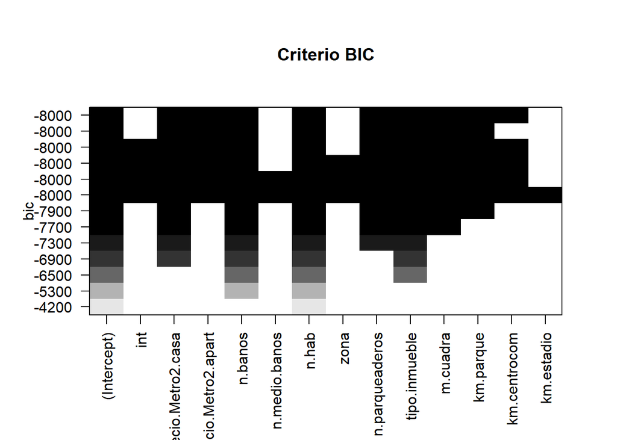

```r
max.model.formula <- formula(max.model)
fwd.model <- regsubsets(x=max.model.formula, y=Valor.Venta, data=datos, nvmax=100000, method="forward")
plot(fwd.model, scale="bic", main="Criterio BIC")
```

Modelo con las mejores variables segun el metodo de forward siguiendo el criterio de bic

```r
best.fwd.model <- summary(fwd.model)
best.fwd.model.by.bic <- which.min(best.fwd.model$bic)
vars.fwd.model <- names(coef(fwd.model, best.fwd.model.by.bic))
formula.best.fwd <- as.formula(paste("Valor.Venta ~ 1 + ", paste(vars.fwd.model[2:length(vars.fwd.model)], collapse=" + "), sep=""))
best.model.fwd <- lm(formula.best.fwd, datos)
summary(best.model.fwd)
```

```
##
## Call:
## lm(formula = formula.best.fwd, data = datos)
##
## Residuals:
##     Min      1Q  Median      3Q     Max
## -806.11  -12.29   -0.54   11.01 1435.51
##
## Coefficients:
##                      Estimate Std. Error t value Pr(>|t|)
## (Intercept)         1000.9633    56.7860  17.627  < 2e-16 ***
## precio.Metro2.casa    24.5378     0.9390  26.130  < 2e-16 ***
## precio.Metro2.apart    5.0872     0.6177   8.236 2.82e-16 ***
## n.banos              102.4813     1.6260  63.027  < 2e-16 ***
## n.hab                147.2687     1.9543  75.357  < 2e-16 ***
## n.parqueaderos        32.7520     1.2847  25.494  < 2e-16 ***
## tipo.inmueble        100.2927     1.8658  53.753  < 2e-16 ***
## m.cuadra               5.8725     0.2804  20.946  < 2e-16 ***
## km.parque              1.9325     0.1097  17.614  < 2e-16 ***
## km.centrocom           1.2124     0.3359   3.609 0.000313 ***
## ---
## Signif. codes:  0 '***' 0.001 '**' 0.01 '*' 0.05 '.' 0.1 ' ' 1
##
## Residual standard error: 46.86 on 2526 degrees of freedom
## Multiple R-squared:  0.9588, Adjusted R-squared:  0.9587
## F-statistic:  6536 on 9 and 2526 DF,  p-value: < 2.2e-16
```

### Stepwise backward

Grafico de las variables usando el criterio de BIC

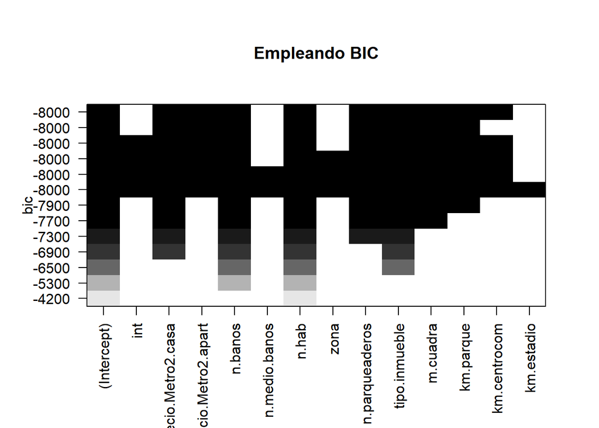

```r
bwd.model <- regsubsets(x=max.model.formula, y=Valor.Venta, datos, nvmax=100000, method="backward")
plot(bwd.model, scale="bic", main="Empleando BIC")
```

Modelo con las mejores variables segun el metodo de backward siguiendo el criterio de bic

```r
best.bwd.model <- summary(bwd.model)
best.bwd.model.by.bic <- which.min(best.bwd.model$bic)
vars.bwd.model <- names(coef(bwd.model, best.bwd.model.by.bic))
formula.best.bwd <- as.formula(paste("Valor.Venta ~ 1 + ", paste(vars.bwd.model[2:length(vars.bwd.model)], collapse=" + "), sep=""))
best.model.bwd <- lm(formula.best.bwd, datos)
summary(best.model.bwd)
```

```
##
## Call:
## lm(formula = formula.best.bwd, data = datos)
##
## Residuals:
##     Min      1Q  Median      3Q     Max
## -806.11  -12.29   -0.54   11.01 1435.51
##
## Coefficients:
##                      Estimate Std. Error t value Pr(>|t|)
## (Intercept)         1000.9633    56.7860  17.627  < 2e-16 ***
## precio.Metro2.casa    24.5378     0.9390  26.130  < 2e-16 ***
## precio.Metro2.apart    5.0872     0.6177   8.236 2.82e-16 ***
## n.banos              102.4813     1.6260  63.027  < 2e-16 ***
## n.hab                147.2687     1.9543  75.357  < 2e-16 ***
## n.parqueaderos        32.7520     1.2847  25.494  < 2e-16 ***
## tipo.inmueble        100.2927     1.8658  53.753  < 2e-16 ***
## m.cuadra               5.8725     0.2804  20.946  < 2e-16 ***
## km.parque              1.9325     0.1097  17.614  < 2e-16 ***
## km.centrocom           1.2124     0.3359   3.609 0.000313 ***
## ---
## Signif. codes:  0 '***' 0.001 '**' 0.01 '*' 0.05 '.' 0.1 ' ' 1
##
## Residual standard error: 46.86 on 2526 degrees of freedom
## Multiple R-squared:  0.9588, Adjusted R-squared:  0.9587
## F-statistic:  6536 on 9 and 2526 DF,  p-value: < 2.2e-16
```

Variables que seguen el metodo de backward son las mejores

```r
vars.bwd.model
```

```
##  [1] "(Intercept)"         "precio.Metro2.casa"  "precio.Metro2.apart"
##  [4] "n.banos"             "n.hab"               "n.parqueaderos"
##  [7] "tipo.inmueble"       "m.cuadra"            "km.parque"
## [10] "km.centrocom"
```

Variables que seguen el metodo de forward son las mejores

```r
vars.fwd.model
```

```
##  [1] "(Intercept)"         "precio.Metro2.casa"  "precio.Metro2.apart"
##  [4] "n.banos"             "n.hab"               "n.parqueaderos"
##  [7] "tipo.inmueble"       "m.cuadra"            "km.parque"
## [10] "km.centrocom"
```

Los metodos de forward y backward concuerdan en que las variables del mejor modelo son las mismas, por lo cual no es necesario realizar la comparacion de los modelos.

```r
model <- best.model.bwd
```

## Problemas econometricos

Dado a que los datos son de corte transversal, se procedera a realizar la prueba para los problemas econometricos, los cuales son las pruebas de heteroscedasticidad y multicolinealidad.

### Heteroscedasticidad

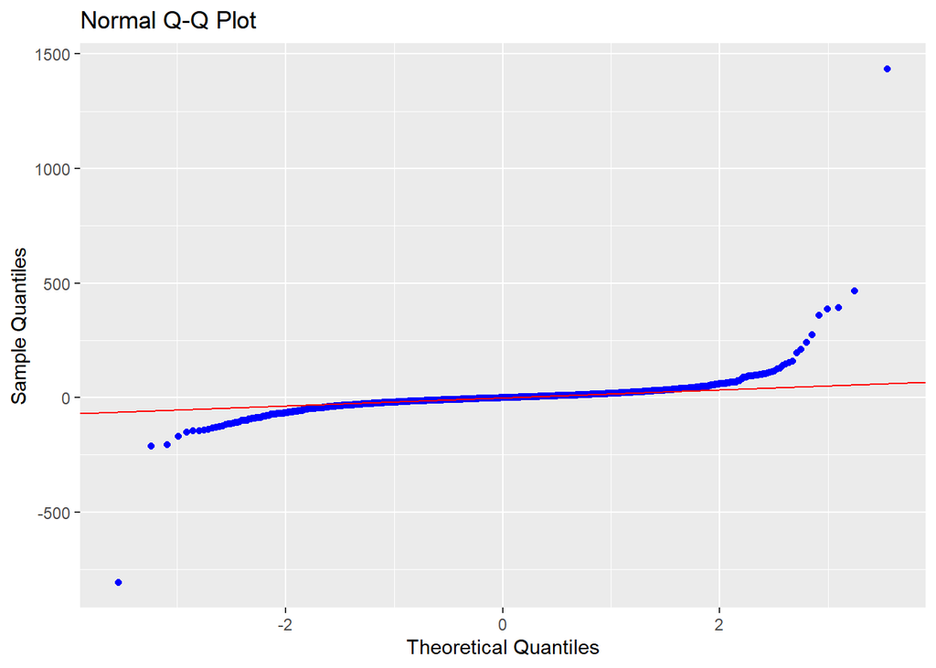

```r
ols_plot_resid_qq(model)
```

```r
res <- residuals(model)
ks.test(resid(model), "pnorm")
```

```
##
##  One-sample Kolmogorov-Smirnov test
##
## data:  resid(model)
## D = 0.447, p-value < 2.2e-16
## alternative hypothesis: two-sided
```

```r
ols_test_normality(res)
```

```
## -----------------------------------------------
##        Test             Statistic       pvalue
## -----------------------------------------------
## Shapiro-Wilk              0.4627         0.0000
## Kolmogorov-Smirnov        0.1929         0.0000
## Cramer-von Mises         202.6583        0.0000
## Anderson-Darling         234.2904        0.0000
## -----------------------------------------------
```

Los datos no siguen una distribucion normal, por lo que no son confiables, por lo cual se va a realizar la prueba de Breusch-Pagan estudentizada.

Prueba de Breusch-Pagan

```r
bptest(model, studentize=TRUE)
```

```
##
##  studentized Breusch-Pagan test
##
## data:  model
## BP = 13.287, df = 9, p-value = 0.15
```

De la prueba se puede concluir que no hay problemas de heteroscedasticidad, ya que no se puede rechazar la hipotesis nula de homoscedasticidad.

Prueba de White

```r
attach(datos)
white_lm(model, interactions=T)
```

```
## # A tibble: 1 x 5
##   statistic p.value parameter method       alternative
##       <dbl>   <dbl>     <dbl> <chr>        <chr>
## 1      55.5   0.417        54 White's Test greater
```

De la prueba de white se puede concluir que no se puede rechazar la hipotesis nula de homoscedastidad, por lo cual se puede concluir que el modelo no tiene problemas de heteroscedasticidad.

### Multicolinealidad

Prueba de VIF

```r
vif(model)
```

```
##  precio.Metro2.casa precio.Metro2.apart             n.banos               n.hab
##            1.003937            1.003288            3.103930            3.110764
##      n.parqueaderos       tipo.inmueble            m.cuadra           km.parque
##            1.003110            1.002731            1.002489            1.002003
##        km.centrocom
##            1.001875
```

Ninguno de las variables del mnodelo posee un VIF alto, por lo cual no se debe corregir nada.

## Predicciones

```r
train.control <- trainControl(method="cv", number=5)
modelcv <- train(formula.best.bwd, datos, method="lm", trControl=train.control)
summary(modelcv)
```

```
##
## Call:
## lm(formula = .outcome ~ ., data = dat)
##
## Residuals:
##     Min      1Q  Median      3Q     Max
## -806.11  -12.29   -0.54   11.01 1435.51
##
## Coefficients:
##                      Estimate Std. Error t value Pr(>|t|)
## (Intercept)         1000.9633    56.7860  17.627  < 2e-16 ***
## precio.Metro2.casa    24.5378     0.9390  26.130  < 2e-16 ***
## precio.Metro2.apart    5.0872     0.6177   8.236 2.82e-16 ***
## n.banos              102.4813     1.6260  63.027  < 2e-16 ***
## n.hab                147.2687     1.9543  75.357  < 2e-16 ***
## n.parqueaderos        32.7520     1.2847  25.494  < 2e-16 ***
## tipo.inmueble        100.2927     1.8658  53.753  < 2e-16 ***
## m.cuadra               5.8725     0.2804  20.946  < 2e-16 ***
## km.parque              1.9325     0.1097  17.614  < 2e-16 ***
## km.centrocom           1.2124     0.3359   3.609 0.000313 ***
## ---
## Signif. codes:  0 '***' 0.001 '**' 0.01 '*' 0.05 '.' 0.1 ' ' 1
##
## Residual standard error: 46.86 on 2526 degrees of freedom
## Multiple R-squared:  0.9588, Adjusted R-squared:  0.9587
## F-statistic:  6536 on 9 and 2526 DF,  p-value: < 2.2e-16
```

```r
nuevo.dato <- data.frame(precio.Metro2.casa=7.5 ,precio.Metro2.apart=5.5, n.banos=3, n.hab=2, n.parqueaderos=2, tipo.inmueble=0, m.cuadra=200, km.parque=15, km.centrocom=5)
predict(modelcv, nuevo.dato, interval="prediction", level=0.95)
```

```
##        1
## 3090.007
```

Para los datos del nuevo inmueble que se ingresaron el nuevo valor del precio es de 3090.007 millones de pesos.